# Practical Machine Learning - Weight Lifting Final Project

C Whitehead

10/22/2021

## Introduction

Using devices such as Jawbone Up, Nike FuelBand, and Fitbit it is now possible to collect a large amount of data about personal activity relatively inexpensively. These type of devices are part of the quantified self movement – a group of enthusiasts who take measurements about themselves regularly to improve their health, to find patterns in their behavior, or because they are tech geeks. One thing that people regularly do is quantify how much of a particular activity they do, but they rarely quantify how well they do it. In this project, your goal will be to use data from accelerometers on the belt, forearm, arm, and dumbell of 6 participants. They were asked to perform barbell lifts correctly and incorrectly in 5 different ways. More information is available from the website here: http://groupware.les.inf.puc-rio.br/har (see the section on the Weight Lifting Exercise Dataset).

Our outcome variable is classe, a factor variable. For this data set, “participants were asked to perform one set of 10 repetitions of the Unilateral Dumbbell Biceps Curl in 5 different fashions:  
(Class A) - exactly according to the specification  
(Class B) - throwing the elbows to the front  
(Class C) - lifting the dumbbell only halfway  
(Class D) - lowering the dumbbell only halfway  
(Class E) - throwing the hips to the front

Data The training data for this project are available here:

https://d396qusza40orc.cloudfront.net/predmachlearn/pml-training.csv

The test data are available here:

https://d396qusza40orc.cloudfront.net/predmachlearn/pml-testing.csv

## Load the Data

```r
train <- read.csv("pml-training.csv",na.strings = c("NA",""),header=TRUE)
test <- read.csv("pml-testing.csv",na.strings = c("NA",""),header=TRUE)
dim(train) #Show train data dimensions
```

```
[1] 19622   160
```

```r
dim(test) #Show test data dimensions
```

```
[1]  20 160
```

## Data Cleaning and Exploration

There are a lot of missing and/or unused data columns so I removed them from both  
the training and test datasets. Several more columns are dropped because they are  
not needed as predictors. This decreases the number of column variables from  
160 to 53. The number of observations stays the same for both training and test.

```r
dim(cleanTrain) #Show new dimensions of the cleaned train dataset
```

```
[1] 19622    53
```

```r
dim(cleanTest)  #Show new dimensions of the cleaned test dataset
```

```
[1] 20 53
```

```r
str(cleanTest) #Display the list of predictors
```

```
'data.frame':   20 obs. of  53 variables:
 $ roll_belt           : num  123 1.02 0.87 125 1.35 -5.92 1.2 0.43 0.93 114 ...
 $ pitch_belt          : num  27 4.87 1.82 -41.6 3.33 1.59 4.44 4.15 6.72 22.4 ...
 $ yaw_belt            : num  -4.75 -88.9 -88.5 162 -88.6 -87.7 -87.3 -88.5 -93.7 -13.1 ...
 $ total_accel_belt    : int  20 4 5 17 3 4 4 4 4 18 ...
 $ gyros_belt_x        : num  -0.5 -0.06 0.05 0.11 0.03 0.1 -0.06 -0.18 0.1 0.14 ...
 $ gyros_belt_y        : num  -0.02 -0.02 0.02 0.11 0.02 0.05 0 -0.02 0 0.11 ...
 $ gyros_belt_z        : num  -0.46 -0.07 0.03 -0.16 0 -0.13 0 -0.03 -0.02 -0.16 ...
 $ accel_belt_x        : int  -38 -13 1 46 -8 -11 -14 -10 -15 -25 ...
 $ accel_belt_y        : int  69 11 -1 45 4 -16 2 -2 1 63 ...
 $ accel_belt_z        : int  -179 39 49 -156 27 38 35 42 32 -158 ...
 $ magnet_belt_x       : int  -13 43 29 169 33 31 50 39 -6 10 ...
 $ magnet_belt_y       : int  581 636 631 608 566 638 622 635 600 601 ...
 $ magnet_belt_z       : int  -382 -309 -312 -304 -418 -291 -315 -305 -302 -330 ...
 $ roll_arm            : num  40.7 0 0 -109 76.1 0 0 0 -137 -82.4 ...
```

[output cut: 39 more lines]

## Fitting Models - Executive Summary

I decided to fit several classifier models to find the most accurate. I also  
split the cleaned training data into a training set and a test validation set.  
I will use the original cleaned test dataset to test the final selected model.

1. Rpart Model has an accuracy of about 74% or 0.7406967.  
   With 95% CI : (0.7293, 0.7519)
2. LDA Model has an accuracy of about 71% or 0.7099405.  
   With 95% CI : (0.6982, 0.7215)
3. SVM Model has an accuracy of about 94% or 0.9434155.  
   With 95% CI : (0.9372, 0.9492)
4. Random Forest Model has an accuracy of about 99% or 0.9937128.  
   With 95% CI : (0.9913, 0.9956)
5. Combined Boosting Model using “gbm” has an accuracy of 99% or 0.9945624.  
   With 95% CI : (0.9923, 0.9963)

For the Combined Boosting Model, I created an ensemble combining three  
classifier models, the Rpart,the SVM and Random Forest. For the resampling  
method I used “cv” with number of folds set at 10.  
I tried LOOCV (Leave One Out Cross Validation), however it ran too long.

The Combined Model’s accuracy was greater than that of the Rpart and SVM models  
and greater than the accuracy of the Random Forest Classifier. The summary reported from the Combined Model shows that the Random Forest Classifier had the  
largest Relative Influence on the results for outcomes B,C,D and E.

Overall, the Random Forest model and Combined model stood out as the best  
classifiers for this data.

```r
suppressPackageStartupMessages(library(caret))
suppressPackageStartupMessages(library(ggplot2))
# Using the caret package function createDataPartition I split the cleaned data
# into training data and testing(validation) data
set.seed(2021)
inTrain <-createDataPartition(cleanTrain$classe, p = 0.7, list=FALSE)
training <- cleanTrain[inTrain,] #training data
testing <- cleanTrain[-inTrain,] #validation data

training$classe <- as.factor(training$classe) #make train clase variable a factor
testing$classe <- as.factor(testing$classe)   #make test clase variable a factor
```

Create a tree model, Plot the Decision Tree and Show Accuracy

```r
suppressPackageStartupMessages(library(rpart))
suppressPackageStartupMessages(library(rpart.plot))
classFit <- rpart(classe ~ ., data=training,method="class")
classPred <- predict(classFit, testing, type = "class") #predict on validation data
confusionMatrix(classPred,testing$classe)$overall[1]
```

```
 Accuracy
0.7406967
```

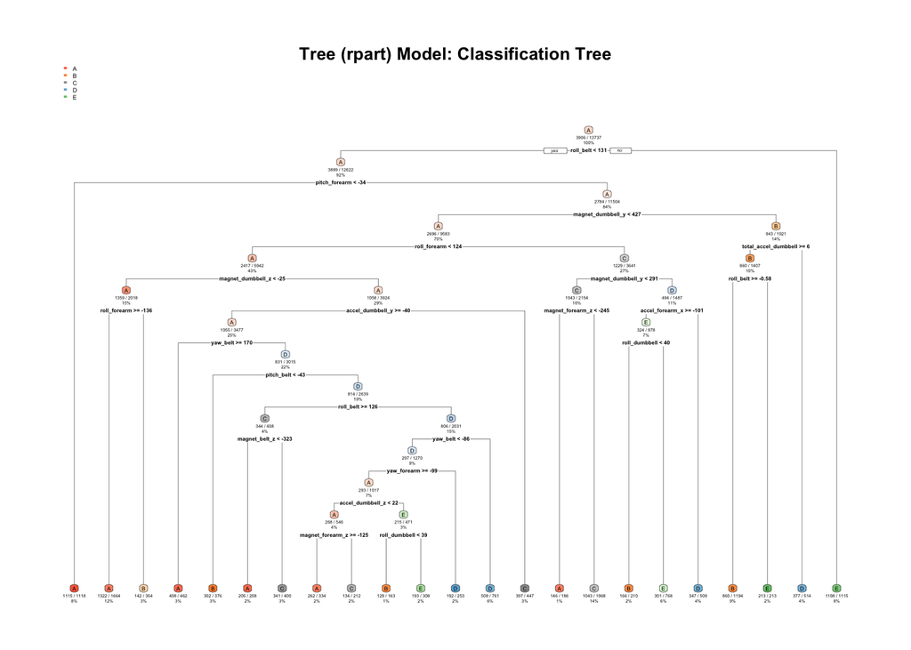

```r
rpart.plot(classFit, main="Tree (rpart) Model: Classification Tree", extra=102, under=TRUE, faclen=1)
```

```r
library(caret)
ldaFit <- train(classe ~ ., data=training,method="lda",
                  trControl=trainControl(method="cv",number=10,verboseIter = FALSE))
ldaPred <- predict(ldaFit, testing) #predict using validation data
#plot(ldaPred,main="LDA Model Outcomes",col="lightgray")
confusionMatrix(ldaPred,testing$classe)$overall[1]
```

```
 Accuracy
0.7099405
```

```r
suppressPackageStartupMessages(library(e1071))
svmFit <- svm(classe ~ ., data=training)
svmPred <- predict(svmFit,testing) #predict using validation data
#plot(svmPred,main="SVM Model Outcomes",col="blue")
confusionMatrix(svmPred, testing$classe)$overall[1]
```

```
 Accuracy
0.9434155
```

```r
suppressPackageStartupMessages(library(caret))
rfFit <- train(classe ~.,method="rf",data=training,verbose=FALSE,
                trControl=trainControl(method="cv",number=10,verboseIter = FALSE))
rfPred <- predict(rfFit,testing) #predict using validation data
#plot(rfPred,main="Random Forest Model Outcomes",col="green")
confusionMatrix(rfPred, testing$classe)$overall[1]
```

```
 Accuracy
0.9937128
```

Create a Combined Boosting Classifier Model, Plot Outcomes and Show Accuracy

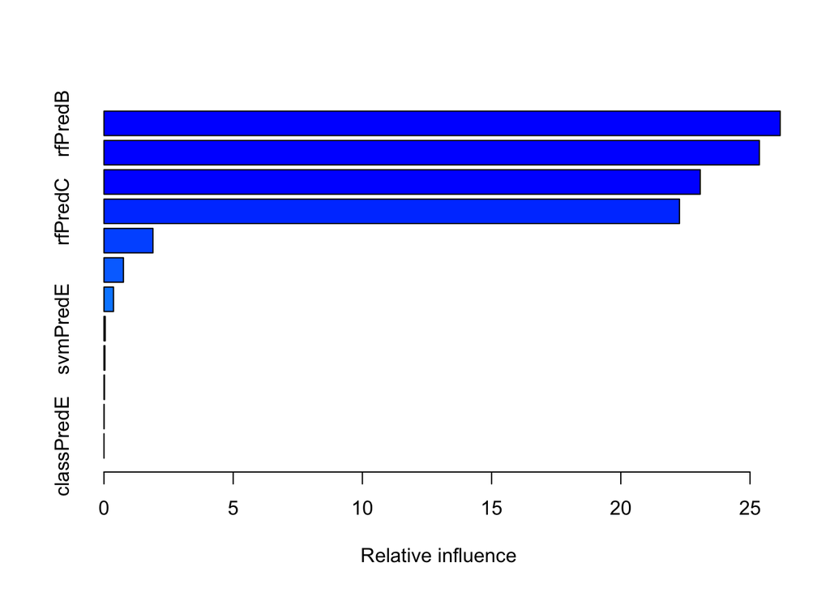

```
                  var      rel.inf
rfPredB       rfPredB 2.616739e+01
rfPredE       rfPredE 2.536068e+01
rfPredD       rfPredD 2.307366e+01
rfPredC       rfPredC 2.227001e+01
svmPredC     svmPredC 1.895094e+00
svmPredD     svmPredD 7.527786e-01
svmPredB     svmPredB 3.685417e-01
svmPredE     svmPredE 4.798299e-02
classPredC classPredC 3.741472e-02
classPredD classPredD 2.068633e-02
classPredB classPredB 5.224283e-03
classPredE classPredE 5.324435e-04
```

```r
suppressPackageStartupMessages(library(caret))
#Fit a model that combines predictors
predDF <- data.frame(classPred,svmPred,rfPred, classe=testing$classe)
combModFit <- train(classe ~.,method="gbm",data=predDF,verbose=FALSE,
                trControl=trainControl(method="cv",number=10,verboseIter = FALSE))
combPred <- predict(combModFit,predDF)
summary(combModFit)
```

```r
#plot(combPred,main="Combined Boosting Model Outcomes",col="red")
confusionMatrix(combPred, testing$classe)$overall[1]
```

```
 Accuracy
0.9945624
```

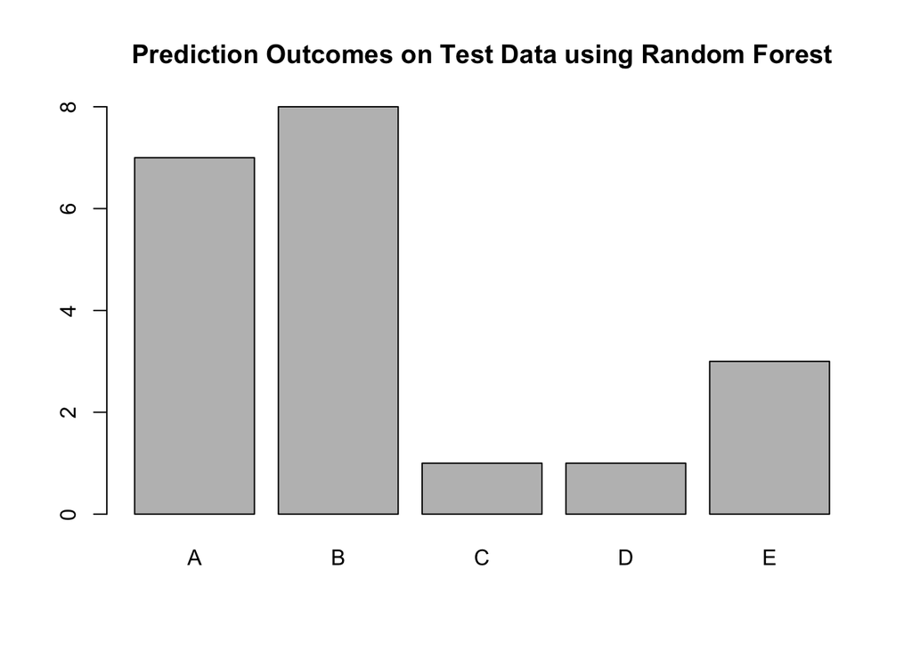

```r
# apply rfFit to real test dataset with 20 observations
rftestPred <- predict(rfFit, newdata=cleanTest, type="raw")
#rftestPred
plot(rftestPred,main="Prediction Outcomes on Test Data using Random Forest")
```

## Plots and Graphs

Graphs related to the cleaned training data pml-training:

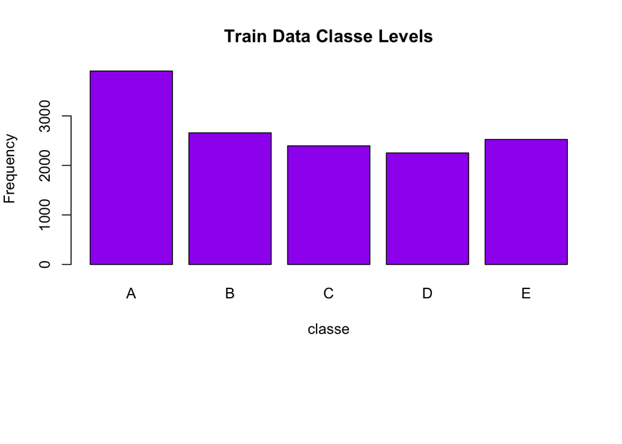

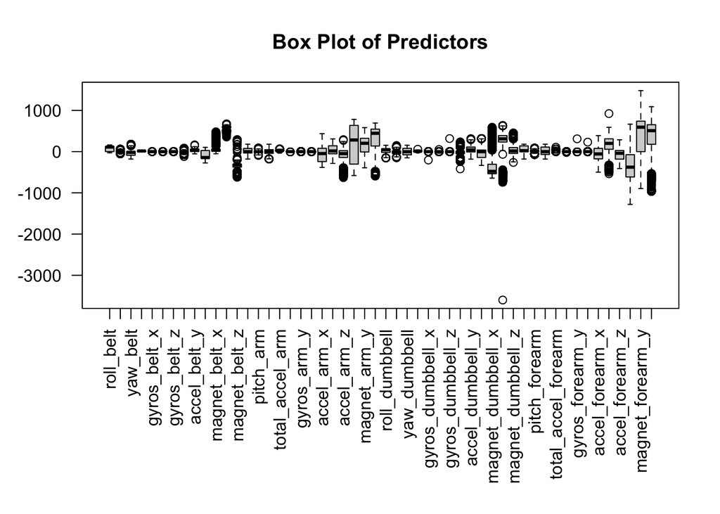

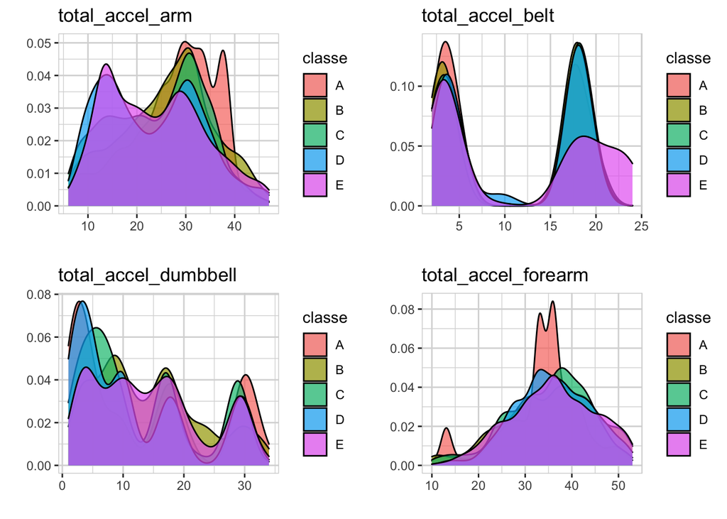